# Reading Activity Data

Charles Westby

11/13/2017

# Reading Activity Data

## Loading and Processing Data

Here is where I imported and processed the data.

```r
#loading packages
library(dplyr)
library(ggplot2)

#importing the data
url <- download.file("https://d396qusza40orc.cloudfront.net/repdata%2Fdata%2Factivity.zip", destfile = "ActivityData.zip")
file <- unzip("ActivityData.zip")
Activity_Data <- read.csv("activity.csv")

#Making the Date column into a Date class for analysis
Activity_Data$date <- as.Date(Activity_Data$date)
```

## Finding Mean Total Number of Steps Per Day

Here is where I performed the analysis. First I found the total number of steps per day

```r
# Finding the total number of steps per day
Total_Steps <- Activity_Data %>%
  group_by(date) %>% #grouping data
  summarize(total_steps = sum(steps)) #finding total sum each day
Total_Steps
```

```
## Source: local data frame [61 x 2]
##
##          date total_steps
##        (date)       (int)
## 1  2012-10-01          NA
## 2  2012-10-02         126
## 3  2012-10-03       11352
## 4  2012-10-04       12116
## 5  2012-10-05       13294
## 6  2012-10-06       15420
## 7  2012-10-07       11015
## 8  2012-10-08          NA
## 9  2012-10-09       12811
## 10 2012-10-10        9900
## ..        ...         ...
```

Then I plotted a histogram of the range for steps each day

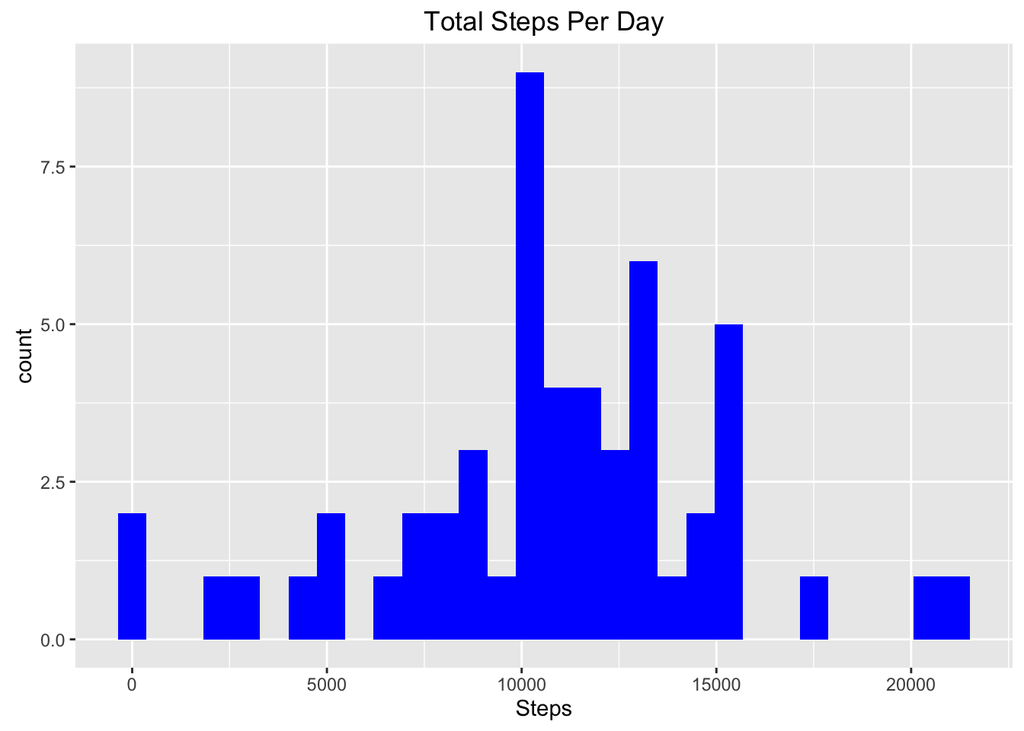

```r
ggplot(Total_Steps, aes(x = total_steps)) +
  geom_histogram(fill = "blue") +
  labs(x = "Steps", title = "Total Steps Per Day")
```

Then I found the mean and median of the total number of steps per day

```r
steps_mean <- mean(Total_Steps$total_steps, na.rm = TRUE)
steps_mean
```

```
## [1] 10766.19
```

```r
steps_median <- median(Total_Steps$total_steps, na.rm = TRUE)
steps_median
```

```
## [1] 10765
```

## Average Daily Activity Pattern

Here I found how many steps on average were take for each 5 minute interval in the day.

```r
Average_Daily <- Activity_Data %>%
  group_by(interval) %>% #grouping data by interval
  summarize(steps_avg = mean(steps, na.rm = TRUE)) #finding daily mean
Average_Daily
```

```
## Source: local data frame [288 x 2]
##
##    interval steps_avg
##       (int)     (dbl)
## 1         0 1.7169811
## 2         5 0.3396226
## 3        10 0.1320755
## 4        15 0.1509434
## 5        20 0.0754717
## 6        25 2.0943396
## 7        30 0.5283019
## 8        35 0.8679245
## 9        40 0.0000000
## 10       45 1.4716981
## ..      ...       ...
```

Next I plotted a time series plot of the average steps taken at every 5 minute interval

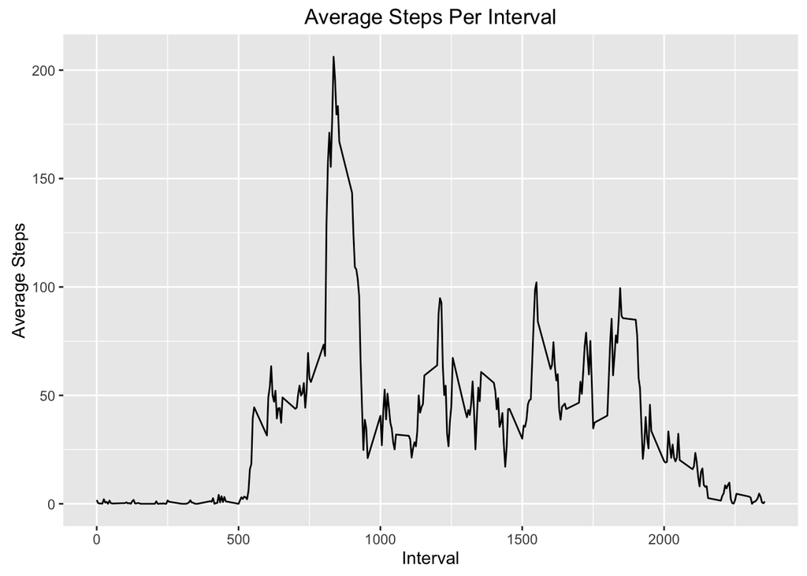

```r
ggplot(Average_Daily, aes(x = interval, y = steps_avg)) +
  geom_line() +
  labs(x = "Interval", y = "Average Steps",
       title = "Average Steps Per Interval")
```

Then I found which interval had the maximum number of steps per day

```r
#Finding the interval with the highest number of steps on average
max <- Average_Daily[which.max(Average_Daily$steps_avg), ]
max
```

```
## Source: local data frame [1 x 2]
##
##   interval steps_avg
##      (int)     (dbl)
## 1      835  206.1698
```

## Imputing Missing Values

First I found the total number of missing values or (NA’s) in the dataset

```r
total_na <- sum(is.na(Activity_Data$steps)) #finding missing values
total_na
```

```
## [1] 2304
```

```r
Activity_Data_2 <- Activity_Data #creating second dataset
ind <- which(is.na(Activity_Data_2$steps)) #finding missing values
Activity_Data_2[ind, "steps"] <- median(Average_Daily$steps_avg) #subbing median steps per interval
```

## New Average Daily Pattern

Next I calculated the total steps for each day in the new dataset. Then I created a histogram showing the total number of steps per day.

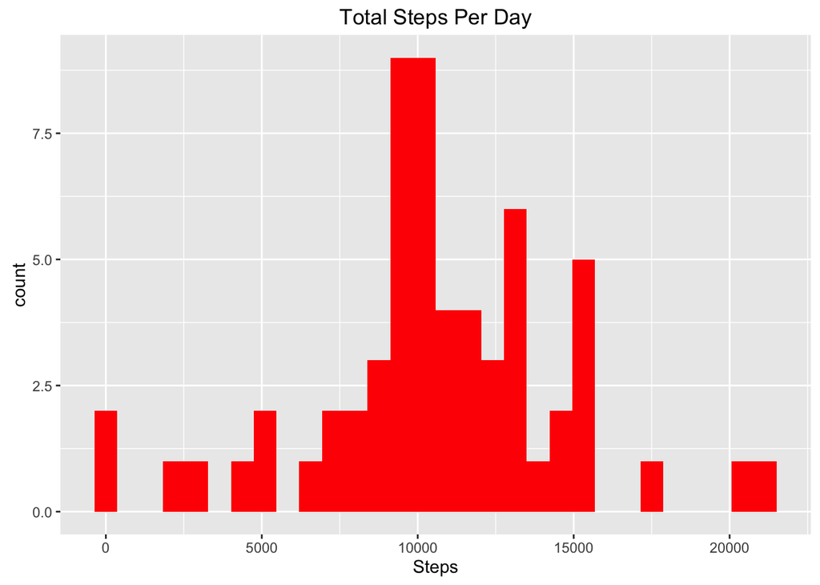

```r
Total_Steps_2 <- Activity_Data_2 %>%
  group_by(date) %>%
  summarize(total_steps = sum(steps))

ggplot(Total_Steps_2, aes(x = total_steps)) +
  geom_histogram(fill = "red") +
  labs(x = "Steps", title = "Total Steps Per Day")
```

I also found the new mean and the new median for imputed dataset

```r
steps_mean <- mean(Total_Steps_2$total_steps, na.rm = TRUE)
steps_mean
```

```
## [1] 10642.7
```

```r
steps_median <- median(Total_Steps_2$total_steps, na.rm = TRUE)
steps_median
```

```
## [1] 10395
```

After imputing the data with the median of steps per interval, there’s a large increase in the number that was used to impute the data. This increase is obvious when comparing the histograms of the Total Steps Per Day for the two datasets. The change in the mean was about 100 steps per day. The change in the median was about 300 steps per day. Further analysis will show what other effects this change has on the datasets.

## Difference Between Weekday and Weekend Activity Patterns

Here I added a column called Weekdays and created two vectors that I used to subset the data. Next I created two datasets based on Weekdays and Weekends. Then for each one I found the mean steps per interval.

```r
#Adding a new column called Weekdays
Activity_Data_2_Days <- Activity_Data_2 %>%
  mutate(Weekday = weekdays(Activity_Data_2$date))

#Forming vector for Weekdays and one for Weekends
Weekdays <- c("Monday", "Tuesday", "Wednesday", "Thursday", "Friday")
Weekends <- c("Saturday", "Sunday")

#Forming Weekday Data Set
Weekday_Activity <- Activity_Data_2_Days %>%
  filter(Weekday %in% Weekdays)

#Finding the mean of steps per interval on weekdays
Average_Daily_weekday <- Weekday_Activity %>%
  group_by(interval) %>%
  summarize(steps_avg = mean(steps, na.rm = TRUE))

#Forming Weekend Dataset
Weekend_Activity <- Activity_Data_2_Days %>%
  filter(Weekday %in% Weekends)

#Finding mean of steps per inerval on weekends
Average_Daily_weekend <- Weekend_Activity %>%
  group_by(interval) %>%
  summarize(steps_avg = mean(steps, na.rm = TRUE))
```

## Plot of Intervals Per Step on Weekdays and Weekends

Finally I put two time series plots, side by side, containing the steps taken per interval on weekdays and weekends.

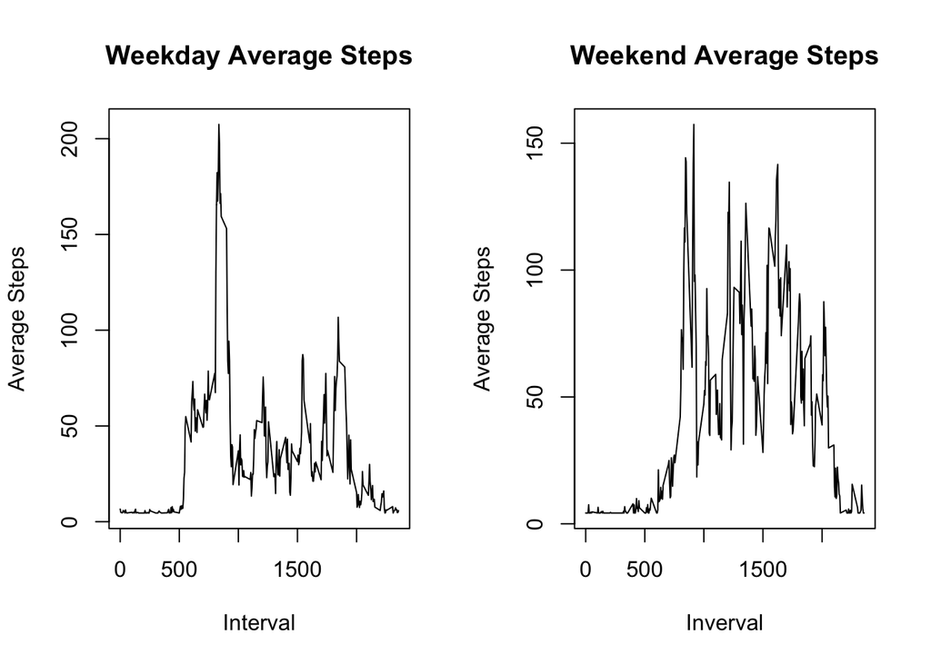

```r
par(mfrow = c(1, 2))
plot(Average_Daily_weekday$interval, Average_Daily_weekday$steps_avg,
     type = "l", xlab = "Interval", ylab = "Average Steps",
     main = "Weekday Average Steps")
plot(Average_Daily_weekend$interval, Average_Daily_weekend$steps_avg,
     type = "l", xlab = "Inverval", ylab = "Average Steps",
     main = "Weekend Average Steps")
```